# Chapter 4 data analysis exercises

Silja Tammi

11/24/2023

# Introduction to Open Data Science - Course Project

### About the project

*Write a short description about the course and add a link to your GitHub repository here. This is an R Markdown (.Rmd) file so you should use R Markdown syntax.*

## Course description

The name of this course refers to THREE BIG THEMES: 1) Open Data, 2) Open Science, and 3) Data Science. These themes are summarized briefly as follows:

1. Open Data

There are more and more open data sets available. Utilizing and sharing data is an essential skill for researchers in all fields. During this course we use open data sets from different sources and learn to prepare them for different analyses. You will explore, analyse and interpret data from real world applications.

2. Open Science

Science thrives to be open. Repeating or reproducing the results is a common aim in any branch of science, but it is not always easy or simple. Sharing data is not enough for reproducibility. What is also needed, is using openly available software tools and methods as well as sharing your code and results. You will learn these skills during this course, using state-of-the-art tools.

3. Data Science

Data Science is the name for the data driven world of Statistics. Nowadays, finding or collecting data is not a problem. Instead, the challenges are in extracting knowledge and discovering the patterns behind the data. It requires skills of coding, programming, and modelling, as well as visualizing and analysing. You will face all these topics on this course.

## Contents of the course:

1 Tools and methods for open and reproducible research  
R, RStudio, R Markdown, GitHub  
2 Regression and model validation  
3 Logistic regression  
4 Clustering and classification  
Discriminant analysis  
K-means clustering  
5 Dimensionality reduction techniques  
Principal component analysis  
Multiple correspondence analysis  
6 Analysis of longitudinal data  
Graphical displays and summary measures  
Linear mixed effects models

After completing this course we will understand the principles and advantages of using open research tools with open data and understand the possibilities of reproducible research. We will know how to use R, RStudio, R Markdown, and GitHub for these tasks and also know how to learn more of these open software tools. We will also know how to apply certain statistical methods of data science, that is, data-driven statistics.

The link to my IODS GitHub repository is: https://github.com/tammisi/IODS-project.git

### My thoughts about the course

I’m looking forward to the course and to learning to use R and Github better at my daily work. I also expect to get a better understanding of performing basic statistical tests. I have been using bioinformatic tools, mostly R, in my PhD project, but I want to learn to be more efficient and organized in my work. I am also just starting with regression analysis, so this course comes at a very good time. So alltogether I have big expectations for the course!

## Reflection on learning experience with excercise set 1

I am familiar with the basics of R, so there wasn’t anything very new for me in exercise set 1. But it is always nice to repeat to refresh and enhance your memory. It was especially good to get some clarity on how to for example filter and modify the data, since there isn’t always a good logic in the way I use all the tools and functions. So one goal for me in this course is to learn to be more efficient and systematic in my R scripts. I haven’t been working with dates much in my previous work with R, so there were also some useful tips about that topic that can come in handy in the future! I’m also looking forward to the exercises on statistical analysis, because I am a novice in that area, but I am just starting to need them in my work.

# Chapter2, Analysis part

*Describe the work you have done this week and summarize your learning.*

- Describe your work and results clearly.
- Assume the reader has an introductory course level understanding of writing and reading R code as well as statistical methods.
- Assume the reader has no previous knowledge of your data or the more advanced methods you are using.

```r
date()
```

```
## [1] "Mon Dec  4 11:26:15 2023"
```

```r
# libraries needed in this exercise
library(tidyverse)
library(readr)
library(ggplot2)
library(GGally)
```

## Exercise 1

### Read the students2014 data into R. Explore the structure and the dimensions of the data and describe the dataset briefly, assuming the reader has no previous knowledge of it.

```r
# read in the
learning2014 <- read_csv("./data/learning2014.csv")
dim(learning2014)
```

```
## [1] 166   7
```

```r
str(learning2014)
```

```
## spc_tbl_ [166 × 7] (S3: spec_tbl_df/tbl_df/tbl/data.frame)
##  $ gender  : chr [1:166] "F" "M" "F" "M" ...
##  $ age     : num [1:166] 53 55 49 53 49 38 50 37 37 42 ...
##  $ attitude: num [1:166] 3.7 3.1 2.5 3.5 3.7 3.8 3.5 2.9 3.8 2.1 ...
##  $ deep    : num [1:166] 3.58 2.92 3.5 3.5 3.67 ...
##  $ stra    : num [1:166] 3.38 2.75 3.62 3.12 3.62 ...
##  $ surf    : num [1:166] 2.58 3.17 2.25 2.25 2.83 ...
##  $ points  : num [1:166] 25 12 24 10 22 21 21 31 24 26 ...
##  - attr(*, "spec")=
##   .. cols(
##   ..   gender = col_character(),
##   ..   age = col_double(),
##   ..   attitude = col_double(),
##   ..   deep = col_double(),
##   ..   stra = col_double(),
##   ..   surf = col_double(),
##   ..   points = col_double()
##   .. )
```

Answer:  
The dataset has 166 rows and 7 columns. The data consists of results from a survey on student’s attitudes towards statistics and their exam points. In the data we have variables like `gender` and `age`, as well as `attitude`, which is student’s global attitude toward statistics, and also student’s answers to questions that have bee grouped by their relatedness to deep (`deep`), surface (`surf`) and strategic (`stra`) learning and that have been scaled back to the original 1-5 scale by taking the mean.

## Exercise 2

### Show a graphical overview of the data and show summaries of the variables in the data. Describe and interpret the outputs, commenting on the distributions of the variables and the relationships between them.

```r
# get summary of variables
summary(learning2014)
```

```
##     gender               age           attitude          deep
##  Length:166         Min.   :17.00   Min.   :1.400   Min.   :1.583
##  Class :character   1st Qu.:21.00   1st Qu.:2.600   1st Qu.:3.333
##  Mode  :character   Median :22.00   Median :3.200   Median :3.667
##                     Mean   :25.51   Mean   :3.143   Mean   :3.680
##                     3rd Qu.:27.00   3rd Qu.:3.700   3rd Qu.:4.083
##                     Max.   :55.00   Max.   :5.000   Max.   :4.917
##       stra            surf           points
##  Min.   :1.250   Min.   :1.583   Min.   : 7.00
##  1st Qu.:2.625   1st Qu.:2.417   1st Qu.:19.00
##  Median :3.188   Median :2.833   Median :23.00
##  Mean   :3.121   Mean   :2.787   Mean   :22.72
##  3rd Qu.:3.625   3rd Qu.:3.167   3rd Qu.:27.75
##  Max.   :5.000   Max.   :4.333   Max.   :33.00
```

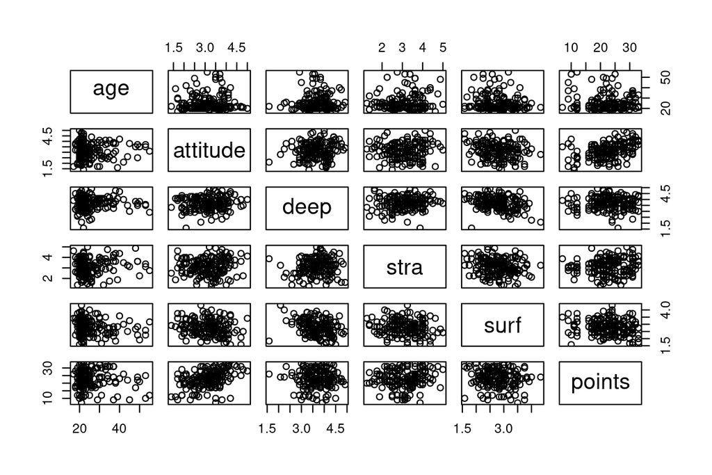

```r
# draw a scatter plot matrix of the variables in learning2014.
# [-1] excludes the first column (gender)
pairs(learning2014[-1])
```

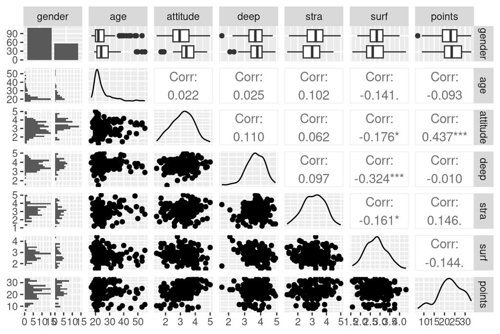

```r
# create a more advanced plot matrix with ggpairs()
ggpairs(learning2014, mapping = aes(), lower = list(combo = wrap("facethist", bins = 20)))
```

Answer:  
In the summary we can see that age of the participants ranges between 17 and 55, mean being 26. Attitudes on 1-5 scale range from 1.4 to 5.0, mean is 3.1. Exam points range from 7.0 to 33.0 and the mean is 22.7.

From the plot matrix we can see that attitude correlates strongly with points (cor=0.437) and also answers related to surface and deep learning correlate with each other.

## Exercise 3

### Choose three variables as explanatory variables and fit a regression model where exam points is the target (dependent, outcome) variable. Show a summary of the fitted model and comment and interpret the results. Explain and interpret the statistical test related to the model parameters. If an explanatory variable in your model does not have a statistically significant relationship with the target variable, remove the variable from the model and fit the model again without it

```r
# I choose gender, attitude, and deep as the explanatory variables

# fit a regression model
learning.lm <- lm(points ~ gender + attitude + deep, data= learning2014)
summary(learning.lm)
```

```
##
## Call:
## lm(formula = points ~ gender + attitude + deep, data = learning2014)
##
## Residuals:
##      Min       1Q   Median       3Q      Max
## -17.0364  -3.2315   0.3561   3.9436  11.0859
##
## Coefficients:
##             Estimate Std. Error t value Pr(>|t|)
## (Intercept)  13.6240     3.1799   4.284 3.13e-05 ***
## genderM      -0.4633     0.9170  -0.505    0.614
## attitude      3.6657     0.5984   6.125 6.61e-09 ***
## deep         -0.6172     0.7546  -0.818    0.415
## ---
## Signif. codes:  0 '***' 0.001 '**' 0.01 '*' 0.05 '.' 0.1 ' ' 1
##
## Residual standard error: 5.337 on 162 degrees of freedom
## Multiple R-squared:  0.1953, Adjusted R-squared:  0.1804
## F-statistic:  13.1 on 3 and 162 DF,  p-value: 1.054e-07
```

Answer:  
In the model with gender, attitude and deep as eplanatory variables, only attitude is a statistically significant predictor of exam points (p-value < 0.05). The p-value is 6.61e-09, so there is strong evidence that the coefficient cannot be 0 and the null hypotheses (the explanatory variable has no effect on the outcome variable) can be rejected. With every 1 unit change in attitude, the points increase by 3.6657. This model explains only 18% of the variation in exam points, so it isn’t a very good predictor. The coefficient (`estimate`) describes the change in the outcome variable (exam points) by every 1 unit change in the explanatory variable, Std.error shows the standard error of the coefficient, the t-statistic measures the number of standard errors the estimated coefficient is away from the hypothesized value (0), and the p-value expresses the statistical significance of the coefficient.

```r
# remove variables 'gender' and 'deep' because they don't have a statistically significant relationship with the target variable and refit the model

learning.lm <- lm(points ~ attitude, data=learning2014)
summary(learning.lm)
```

```
##
## Call:
## lm(formula = points ~ attitude, data = learning2014)
##
## Residuals:
##      Min       1Q   Median       3Q      Max
## -16.9763  -3.2119   0.4339   4.1534  10.6645
##
## Coefficients:
##             Estimate Std. Error t value Pr(>|t|)
## (Intercept)  11.6372     1.8303   6.358 1.95e-09 ***
## attitude      3.5255     0.5674   6.214 4.12e-09 ***
## ---
## Signif. codes:  0 '***' 0.001 '**' 0.01 '*' 0.05 '.' 0.1 ' ' 1
##
## Residual standard error: 5.32 on 164 degrees of freedom
## Multiple R-squared:  0.1906, Adjusted R-squared:  0.1856
## F-statistic: 38.61 on 1 and 164 DF,  p-value: 4.119e-09
```

## Exercise 4

### Using a summary of your fitted model, explain the relationship between the chosen explanatory variables and the target variable (interpret the model parameters). Explain and interpret the multiple R-squared of the model

Answer:  
After removing the non-significant variables, attitude is still statistically significant (p-value now 4.12e-09). The predicted change in exam points per one unit change in attitude is 3.5255. Standard error is 0.57 so pretty low. T-value also indicates that the estimated coefficient is 6.2 standard errors away from 0. The model now explains 18.6% (adjusted R-squared = 0.1856) of the variation in exam points. So the results didn’t change much when removing the non-significant variables.

## Exercise 5

### Produce the following diagnostic plots: Residuals vs Fitted values, Normal QQ-plot and Residuals vs Leverage. Explain the assumptions of the model and interpret the validity of those assumptions based on the diagnostic plots

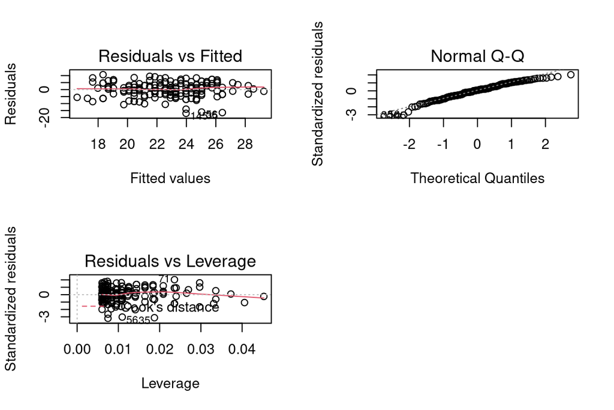

```r
par(mfrow=c(2,2))
plot(learning.lm, which=c(1,2,5))
```

Answer:  
Residuals vs. fitted plot show that the points are quite nicely evenly distributed and don’t show any clear pattern, show the model seem to fit the data well. No modifications such as quadratic terms, are needed. Also the QQ plot showing the residuals against the same from a normal distribution look like a pretty even diagonal line, except some small deviations in the lower and higher ends, so the data seems to be normally distributed. The residuals vs leverage plot doesn’t show any strong outliers that would have a significant effect on the results. So according to the diagnostic plots, the model seems to perform well on the data.

# Chapter3, Analysis part

## Exercise 1

#### *Read the joined student alcohol consumption data into R*

```r
alc <- read.csv("./data/alc.csv")
dim(alc)
```

```
## [1] 370  36
```

```r
head(alc)
```

```
##   X school sex age address famsize Pstatus Medu Fedu     Mjob     Fjob
## 1 1     GP   F  18       U     GT3       A    4    4  at_home  teacher
## 2 2     GP   F  17       U     GT3       T    1    1  at_home    other
## 3 3     GP   F  15       U     LE3       T    1    1  at_home    other
## 4 4     GP   F  15       U     GT3       T    4    2   health services
## 5 5     GP   F  16       U     GT3       T    3    3    other    other
## 6 6     GP   M  16       U     LE3       T    4    3 services    other
##       reason guardian traveltime studytime schoolsup famsup activities nursery
## 1     course   mother          2         2       yes     no         no     yes
## 2     course   father          1         2        no    yes         no      no
## 3      other   mother          1         2       yes     no         no     yes
## 4       home   mother          1         3        no    yes        yes     yes
## 5       home   father          1         2        no    yes         no     yes
## 6 reputation   mother          1         2        no    yes        yes     yes
##   higher internet romantic famrel freetime goout Dalc Walc health failures paid
## 1    yes       no       no      4        3     4    1    1      3        0   no
## 2    yes      yes       no      5        3     3    1    1      3        0   no
## 3    yes      yes       no      4        3     2    2    3      3        2  yes
## 4    yes      yes      yes      3        2     2    1    1      5        0  yes
## 5    yes       no       no      4        3     2    1    2      5        0  yes
## 6    yes      yes       no      5        4     2    1    2      5        0  yes
##   absences G1 G2 G3 alc_use high_use
## 1        5  2  8  8     1.0    FALSE
## 2        3  7  8  8     1.0    FALSE
## 3        8 10 10 11     2.5     TRUE
## 4        1 14 14 14     1.0    FALSE
## 5        2  8 12 12     1.5    FALSE
## 6        8 14 14 14     1.5    FALSE
```

## Exercise 2

#### *Print out the names of the variables in the data and describe the data set briefly, assuming the reader has no previous knowledge of it.*

```r
names(alc)
```

```
##  [1] "X"          "school"     "sex"        "age"        "address"
##  [6] "famsize"    "Pstatus"    "Medu"       "Fedu"       "Mjob"
## [11] "Fjob"       "reason"     "guardian"   "traveltime" "studytime"
## [16] "schoolsup"  "famsup"     "activities" "nursery"    "higher"
## [21] "internet"   "romantic"   "famrel"     "freetime"   "goout"
## [26] "Dalc"       "Walc"       "health"     "failures"   "paid"
## [31] "absences"   "G1"         "G2"         "G3"         "alc_use"
## [36] "high_use"
```

The data is combined from two identical questionnaires related to secondary school student alcohol consumption in Portugal. There are 370 students and 36 variables. There are variables defining student characteristics such as `school`, `sex`, `age` and so on. Numeric variables `failures`, `absences`, `G1`, `G2` and `G3` are rounded averages. `alc_use` is the average of the answers related to weekday and weekend alcohol consumption and `high_use` is a logical variable (TRUE for ‘alc_use’ > 2 and FALSE for ‘alc_use’ <2).

## Exercise 3

#### *The purpose of your analysis is to study the relationships between high/low alcohol consumption and some of the other variables in the data. To do this, choose 4 interesting variables in the data and for each of them, present your personal hypothesis about their relationships with alcohol consumption.*

I choose variables `sex`, `school`, `failures` and `famrel`.  
H0 hypothesis is that the variables have no connection to alcohol consumption among students.  
My H1 hypotheses are:  
- sex is connected to high alcohol use (for sex=M use is higher).  
- there might be differences between the schools  
- higher number of past class failures and poorer quality of family relationships is connected to higher alcohol consumption.

## Exercise 4

#### *Numerically and graphically explore the distributions of your chosen variables and their relationships with alcohol consumption (use for example cross-tabulations, bar plots and box plots). Comment on your findings and compare the results of your exploration to your previously stated hypotheses.*

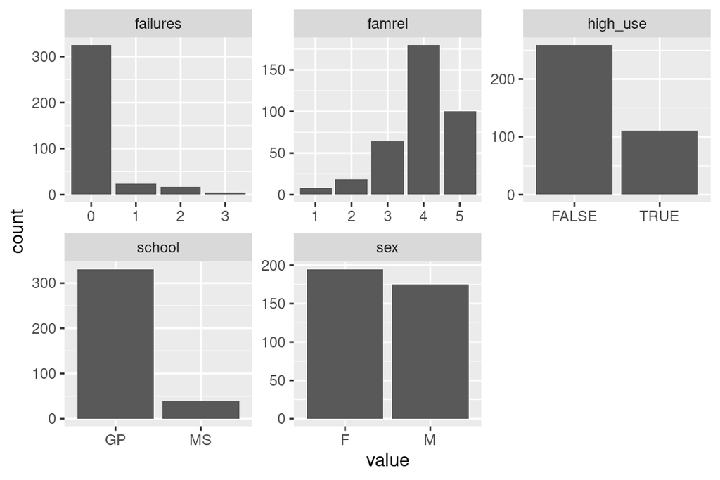

```r
# bar plots of all variables
mydata <- select(alc, c(high_use, school, sex, famrel, failures))
gather(mydata) %>% ggplot(aes(value)) + facet_wrap("key", scales = "free") + geom_bar()
```

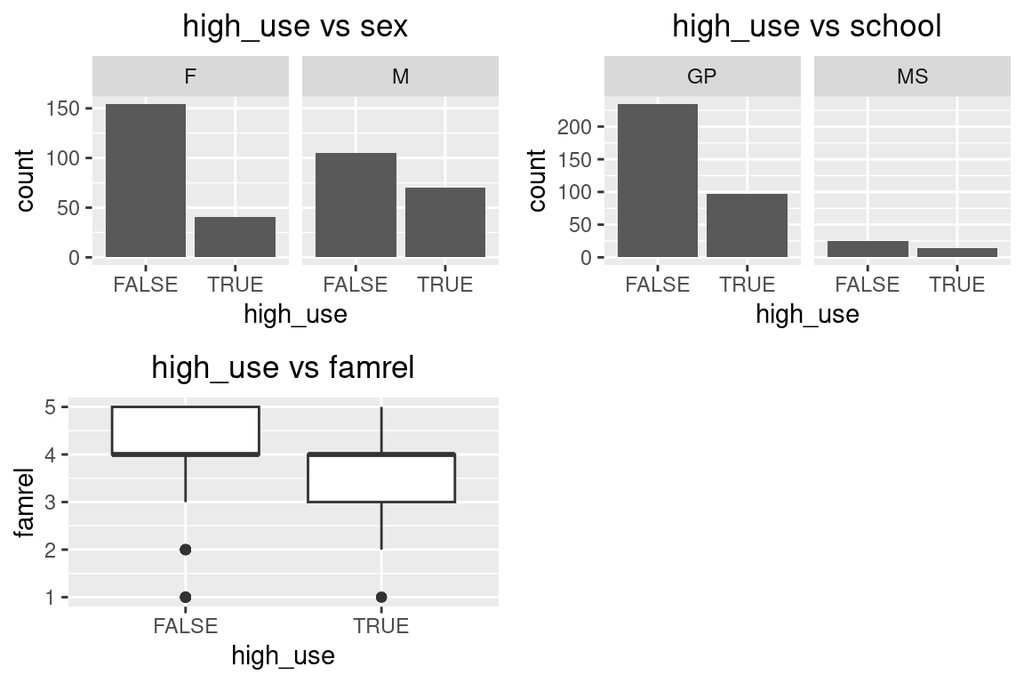

```r
# barplots of non-numerical variables
g1 <- ggplot(alc, aes(x=high_use)) + geom_bar() + facet_wrap('sex') + ggtitle('high_use vs sex') + theme(plot.title = element_text(hjust = 0.5))

g2 <- ggplot(alc, aes(x=high_use)) + geom_bar() + facet_wrap('school') + ggtitle('high_use vs school') + theme(plot.title = element_text(hjust = 0.5))

# boxplots of numerical variables
g3 <- ggplot(alc, aes(x=high_use, y=famrel)) + geom_boxplot() + ggtitle('high_use vs famrel') + theme(plot.title = element_text(hjust = 0.5))

ggarrange(g1,g2,g3)
```

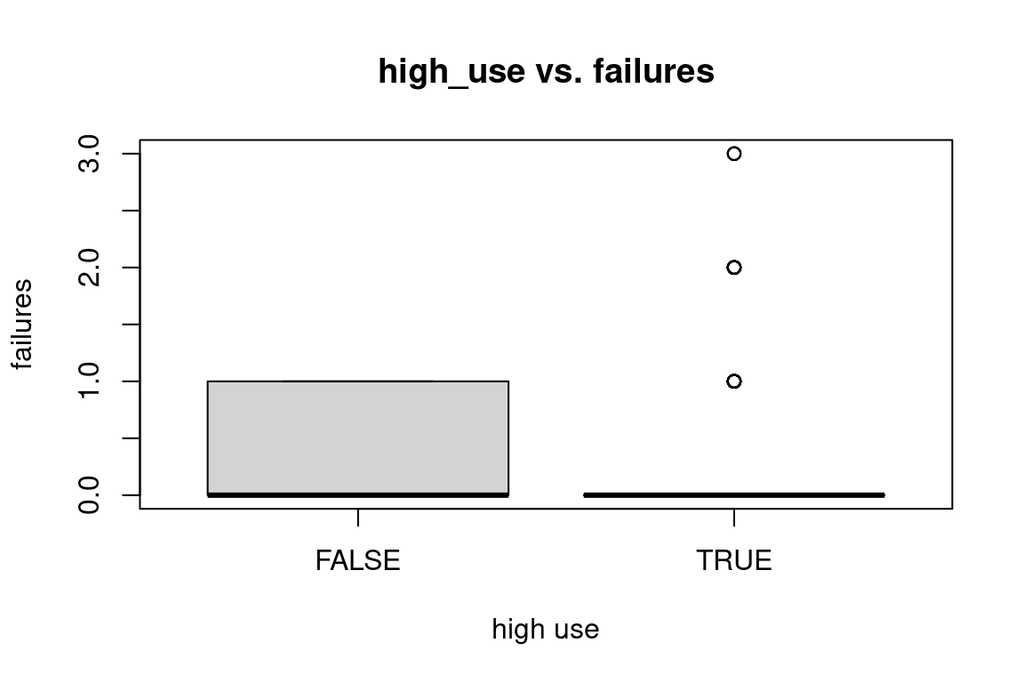

```r
#g4 <- ggplot(alc, aes(x=high_use, y=failures)) + geom_boxplot() + ggtitle('high_use vs failures') + theme(plot.title = element_text(hjust = 0.5))
#g4
# for some reason this doesn't work for failures, so I use boxplot in this case instead:
boxplot(alc$high_use, alc$failures, xlab='high use', ylab='failures', main='high_use vs. failures', names=levels(factor(alc$high_use)))
```

From the first barplot we can see that most students have zero and only very few have 1-3 past failures. Most of the students also have good family relations. High alcohol use is more uncommon than low alcohol use. There are a lot more students from school ‘GP’ than ‘MS’, but the ratio between female and male students is pretty even.

The barplot of **high_use vs. sex** indicates that larger proportion of male students are high users of alcohol, so this indicates that the hypotheses could be true.

The barplot of **high_use vs. school** indicates that in both schools the proportion of high users is lower than not high users. Even though the difference is bigger in `GP`, the difference might not be statistically significant.

The barplot of **high_use vs. famrel** indicates that the mean quality of family relations is lower among high users. The hypothesis could therefore be true.

## Exercise 5

#### *Use logistic regression to statistically explore the relationship between your chosen variables and the binary high/low alcohol consumption variable as the target variable*

```r
# fit model
alc.glm <- glm(high_use ~ sex + school + failures + famrel, data = alc, family = "binomial")
summary(alc.glm)
```

```
##
## Call:
## glm(formula = high_use ~ sex + school + failures + famrel, family = "binomial",
##     data = alc)
##
## Deviance Residuals:
##     Min       1Q   Median       3Q      Max
## -1.7345  -0.8246  -0.6257   1.1687   1.9935
##
## Coefficients:
##             Estimate Std. Error z value Pr(>|z|)
## (Intercept)  -0.2982     0.5170  -0.577 0.564098
## sexM          0.9357     0.2415   3.874 0.000107 ***
## schoolMS      0.3071     0.3725   0.824 0.409704
## failures      0.6162     0.2018   3.054 0.002260 **
## famrel       -0.3083     0.1276  -2.415 0.015718 *
## ---
## Signif. codes:  0 '***' 0.001 '**' 0.01 '*' 0.05 '.' 0.1 ' ' 1
##
## (Dispersion parameter for binomial family taken to be 1)
##
##     Null deviance: 452.04  on 369  degrees of freedom
## Residual deviance: 418.96  on 365  degrees of freedom
## AIC: 428.96
##
## Number of Fisher Scoring iterations: 4
```

```r
confint(alc.glm)
```

```
##                  2.5 %      97.5 %
## (Intercept) -1.3226184  0.71249519
## sexM         0.4671197  1.41565633
## schoolMS    -0.4438613  1.02622019
## failures     0.2278800  1.02645318
## famrel      -0.5609504 -0.05862812
```

```r
coef(alc.glm) %>% exp
```

```
## (Intercept)        sexM    schoolMS    failures      famrel
##   0.7421802   2.5490315   1.3594796   1.8518843   0.7346998
```

#### *Present and interpret a summary of the fitted model. Present and interpret the coefficients of the model as odds ratios and provide confidence intervals for them. Interpret the results and compare them to your previously stated hypothesis.*

Seems like `School` is not a signifant variable explaining alcohol consumption (p-value 0.409704). However,`sex` is a highly significant variable (p-value 0.000107). The odds of student being a high user is 2.6 times **higher** (exp(0.94) = 2.55) if he is a male compared with a female, if all other variables are constant.`Failures` is also significant (p-value 0.002260), one unit increase in number of failures **increases** log odds of high use by 0.62 (95% CI 0.23, 1.03) units. `Famrel` is also somewhat significant (p-value 0.015718), every one unit increase in the quality of family relations **decreases** log odds of high use by -0.31 (95% CI -0.56, -0.06) units. so the hypotheses for `sex`, `failures` and `famrel` were correct.

## Exercise 6

#### *Using the variables which, according to your logistic regression model, had a statistical relationship with high/low alcohol consumption, explore the predictive power of you model. Provide a 2x2 cross tabulation of predictions versus the actual values and optionally display a graphic visualizing both the actual values and the predictions. Compute the total proportion of inaccurately classified individuals (= the training error) and comment on all the results. Compare the performance of the model with performance achieved by some simple guessing strategy*

```r
# retrain model with statistically significant variables
alc.glm <- glm(high_use ~ sex + failures + famrel, data=alc, family='binomial')
summary(alc.glm)
```

```
##
## Call:
## glm(formula = high_use ~ sex + failures + famrel, family = "binomial",
##     data = alc)
##
## Deviance Residuals:
##     Min       1Q   Median       3Q      Max
## -1.7465  -0.8333  -0.6359   1.1559   1.9814
##
## Coefficients:
##             Estimate Std. Error z value Pr(>|z|)
## (Intercept)  -0.2321     0.5109  -0.454 0.649564
## sexM          0.9322     0.2413   3.863 0.000112 ***
## failures      0.6144     0.2021   3.040 0.002366 **
## famrel       -0.3159     0.1276  -2.476 0.013273 *
## ---
## Signif. codes:  0 '***' 0.001 '**' 0.01 '*' 0.05 '.' 0.1 ' ' 1
##
## (Dispersion parameter for binomial family taken to be 1)
##
##     Null deviance: 452.04  on 369  degrees of freedom
## Residual deviance: 419.63  on 366  degrees of freedom
## AIC: 427.63
##
## Number of Fisher Scoring iterations: 4
```

```r
# make predictions
probabilities <- predict(alc.glm, type = "response")

# add the predicted probabilities to 'alc'
alc <- mutate(alc, probability = probabilities)

# create logical vector indicating predictions
alc <- mutate(alc, prediction = probabilities > 0.5)

# table the target variable versus the predictions
table(high_use = alc$high_use, prediction = alc$prediction) %>% prop.table() %>% addmargins()
```

```
##         prediction
## high_use      FALSE       TRUE        Sum
##    FALSE 0.65945946 0.04054054 0.70000000
##    TRUE  0.24594595 0.05405405 0.30000000
##    Sum   0.90540541 0.09459459 1.00000000
```

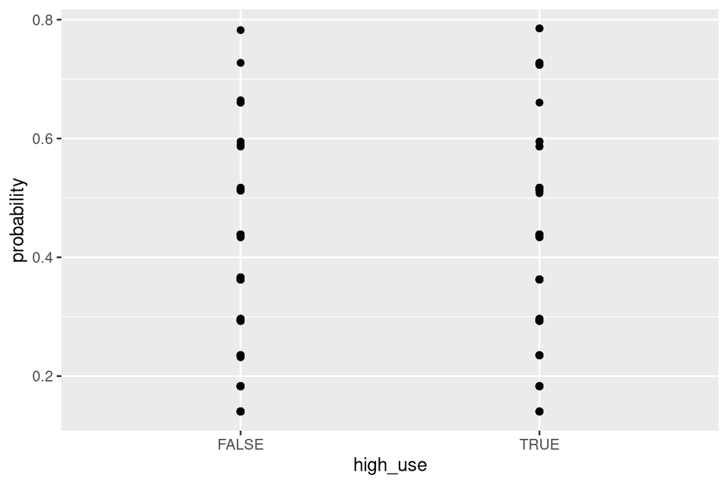

```r
# plot 'high_use' versus 'probability'
ggplot(alc, aes(x = high_use, y = probability)) + geom_point()
```

```r
# define a loss function (mean prediction error)
loss_func <- function(class, prob) {
  n_wrong <- abs(class - prob) > 0.5
  mean(n_wrong)
}

# call loss_func to compute the average number of wrong predictions in the (training) data
loss_func(class = alc$high_use, prob = alc$probability)
```

```
## [1] 0.2864865
```

The training error of the model is 0.286 = 28.6% of classifications are wrong. I guess this is not ideal, but better than gessing (50% chance of classification being right or wrong).

## Exercise 7. **BONUS**

#### *Bonus: Perform 10-fold cross-validation on your model. Does your model have better test set performance (smaller prediction error using 10-fold cross-validation) compared to the model introduced in the Exercise Set (which had about 0.26 error). Could you find such a model?*

```r
# K-fold cross-validation
cv <- cv.glm(data = alc, cost = loss_func, glmfit = alc.glm, K = nrow(alc))

# average number of wrong predictions in the cross validation
cv$delta[1]
```

```
## [1] 0.2891892
```

The test set error (0.289) is not better than the training error (0.286).

## Exercise 8 **BONUS**

#### *Super-Bonus: Perform cross-validation to compare the performance of different logistic regression models (= different sets of predictors). Start with a very high number of predictors and explore the changes in the training and testing errors as you move to models with less predictors. Draw a graph displaying the trends of both training and testing errors by the number of predictors in the model*

```r
# function to calculate train and test error
alc_function <- function(model, Data) {
  probabilities <- predict(model, type = "response")
  Data <- mutate(Data, probability = probabilities)
  Data <- mutate(Data, prediction = probabilities > 0.5)
  print(table(high_use = Data$high_use, prediction = Data$prediction) %>% prop.table() %>% addmargins())
  print(paste0("train error: ", loss_func(class = Data$high_use, prob = Data$probability)))
  cv <- cv.glm(data = Data, cost = loss_func, glmfit = model, K = nrow(Data))
  print(paste0("cv$delta: ", cv$delta[1]))
}


# start with a model with high number of variables as predictors
alc.1 <- select(alc, c(2:4, 6:25, 28:31,36))
alc.glm1 <- glm(high_use ~., data = alc.1, family = 'binomial')
summary(alc.glm1)
```

```
##
## Call:
## glm(formula = high_use ~ ., family = "binomial", data = alc.1)
##
## Deviance Residuals:
##     Min       1Q   Median       3Q      Max
## -1.8095  -0.6842  -0.3740   0.5368   2.8989
##
## Coefficients:
##                  Estimate Std. Error z value Pr(>|z|)
## (Intercept)      -5.25727    3.03561  -1.732 0.083297 .
## schoolMS         -0.32057    0.52486  -0.611 0.541344
## sexM              0.88711    0.32771   2.707 0.006789 **
## age               0.10206    0.14998   0.680 0.496214
## famsizeLE3        0.45316    0.32350   1.401 0.161272
## PstatusT         -0.34942    0.52415  -0.667 0.505005
## Medu              0.06630    0.21987   0.302 0.763006
## Fedu              0.14715    0.19563   0.752 0.451929
## Mjobhealth       -1.14968    0.75199  -1.529 0.126303
## Mjobother        -0.90964    0.49250  -1.847 0.064747 .
## Mjobservices     -0.94817    0.55923  -1.695 0.089983 .
## Mjobteacher      -0.54168    0.68617  -0.789 0.429865
## Fjobhealth        0.33164    1.19631   0.277 0.781611
## Fjobother         0.87998    0.86972   1.012 0.311635
## Fjobservices      1.31772    0.88582   1.488 0.136863
## Fjobteacher      -0.23772    1.03541  -0.230 0.818407
## reasonhome        0.46813    0.38596   1.213 0.225173
## reasonother       1.58250    0.54173   2.921 0.003487 **
## reasonreputation  0.05031    0.41071   0.122 0.902511
## guardianmother   -0.69328    0.36620  -1.893 0.058336 .
## guardianother    -0.30531    0.78460  -0.389 0.697180
## traveltime        0.41657    0.22354   1.864 0.062385 .
## studytime        -0.26555    0.20267  -1.310 0.190112
## schoolsupyes      0.09773    0.46184   0.212 0.832420
## famsupyes        -0.03823    0.32434  -0.118 0.906162
## activitiesyes    -0.50404    0.30982  -1.627 0.103762
## nurseryyes       -0.53578    0.36578  -1.465 0.142979
## higheryes        -0.17048    0.71054  -0.240 0.810380
## internetyes      -0.04812    0.44144  -0.109 0.913193
## romanticyes      -0.56868    0.33272  -1.709 0.087415 .
## famrel           -0.57506    0.16594  -3.465 0.000529 ***
## freetime          0.29178    0.16939   1.723 0.084971 .
## goout             0.83792    0.15217   5.507 3.66e-08 ***
## health            0.19799    0.11309   1.751 0.080001 .
## failures          0.27196    0.27381   0.993 0.320599
## paidyes           0.51832    0.31850   1.627 0.103659
## absences          0.09152    0.02628   3.483 0.000496 ***
## ---
## Signif. codes:  0 '***' 0.001 '**' 0.01 '*' 0.05 '.' 0.1 ' ' 1
##
## (Dispersion parameter for binomial family taken to be 1)
##
##     Null deviance: 452.04  on 369  degrees of freedom
## Residual deviance: 315.42  on 333  degrees of freedom
## AIC: 389.42
##
## Number of Fisher Scoring iterations: 5
```

```r
# apply function to get train and test error
alc_function(alc.glm1, alc.1)
```

```
##         prediction
## high_use      FALSE       TRUE        Sum
##    FALSE 0.64324324 0.05675676 0.70000000
##    TRUE  0.13513514 0.16486486 0.30000000
##    Sum   0.77837838 0.22162162 1.00000000
## [1] "train error: 0.191891891891892"
## [1] "cv$delta: 0.243243243243243"
```

```r
# decrease the amount of variables (remove some of the insignificant variables)
alc.2 <- select(alc, c('sex', 'age', 'Medu', 'Fedu', 'Mjob', 'reason', 'guardian', 'traveltime', 'higher','famrel', 'goout', 'health', 'absences', 'high_use'))

# train model
alc.glm2 <- glm(high_use ~., data = alc.2, family = 'binomial')
summary(alc.glm2)
```

```
##
## Call:
## glm(formula = high_use ~ ., family = "binomial", data = alc.2)
##
## Deviance Residuals:
##     Min       1Q   Median       3Q      Max
## -1.7549  -0.7323  -0.4254   0.6112   2.7109
##
## Coefficients:
##                   Estimate Std. Error z value Pr(>|z|)
## (Intercept)      -3.147567   2.434744  -1.293 0.196090
## sexM              0.985572   0.291620   3.380 0.000726 ***
## age               0.020333   0.125677   0.162 0.871474
## Medu             -0.080218   0.204250  -0.393 0.694509
## Fedu              0.006313   0.171372   0.037 0.970613
## Mjobhealth       -0.643558   0.671539  -0.958 0.337895
## Mjobother        -0.619779   0.436160  -1.421 0.155320
## Mjobservices     -0.472012   0.490653  -0.962 0.336046
## Mjobteacher      -0.176883   0.605425  -0.292 0.770161
## reasonhome        0.379839   0.356512   1.065 0.286681
## reasonother       1.281219   0.484228   2.646 0.008147 **
## reasonreputation -0.128246   0.373793  -0.343 0.731528
## guardianmother   -0.608783   0.335136  -1.817 0.069290 .
## guardianother     0.226093   0.701806   0.322 0.747332
## traveltime        0.368261   0.199638   1.845 0.065089 .
## higheryes        -0.167295   0.640623  -0.261 0.793981
## famrel           -0.507684   0.152603  -3.327 0.000878 ***
## goout             0.858391   0.137201   6.256 3.94e-10 ***
## health            0.171406   0.104502   1.640 0.100960
## absences          0.090320   0.024226   3.728 0.000193 ***
## ---
## Signif. codes:  0 '***' 0.001 '**' 0.01 '*' 0.05 '.' 0.1 ' ' 1
##
## (Dispersion parameter for binomial family taken to be 1)
##
##     Null deviance: 452.04  on 369  degrees of freedom
## Residual deviance: 341.50  on 350  degrees of freedom
## AIC: 381.5
##
## Number of Fisher Scoring iterations: 5
```

```r
# repeat calculations
alc_function(alc.glm2, alc.2)
```

```
##         prediction
## high_use      FALSE       TRUE        Sum
##    FALSE 0.64054054 0.05945946 0.70000000
##    TRUE  0.14594595 0.15405405 0.30000000
##    Sum   0.78648649 0.21351351 1.00000000
## [1] "train error: 0.205405405405405"
## [1] "cv$delta: 0.245945945945946"
```

```r
# remove all unsignificant variables
alc.3 <- select(alc, c('sex', 'reason', 'famrel', 'goout', 'absences', 'high_use'))

# train model
alc.glm3 <- glm(high_use ~., data = alc.3, family = 'binomial')
summary(alc.glm3)
```

```
##
## Call:
## glm(formula = high_use ~ ., family = "binomial", data = alc.3)
##
## Deviance Residuals:
##     Min       1Q   Median       3Q      Max
## -1.8009  -0.7643  -0.4668   0.6793   2.7417
##
## Coefficients:
##                  Estimate Std. Error z value Pr(>|z|)
## (Intercept)      -2.78746    0.70260  -3.967 7.27e-05 ***
## sexM              1.05224    0.26954   3.904 9.47e-05 ***
## reasonhome        0.21453    0.33099   0.648 0.516881
## reasonother       1.04957    0.46137   2.275 0.022912 *
## reasonreputation -0.35415    0.35218  -1.006 0.314607
## famrel           -0.43597    0.14422  -3.023 0.002503 **
## goout             0.79325    0.12775   6.210 5.32e-10 ***
## absences          0.08343    0.02291   3.641 0.000272 ***
## ---
## Signif. codes:  0 '***' 0.001 '**' 0.01 '*' 0.05 '.' 0.1 ' ' 1
##
## (Dispersion parameter for binomial family taken to be 1)
##
##     Null deviance: 452.04  on 369  degrees of freedom
## Residual deviance: 356.63  on 362  degrees of freedom
## AIC: 372.63
##
## Number of Fisher Scoring iterations: 5
```

```r
# repeat calculations
alc_function(alc.glm3, alc.3)
```

```
##         prediction
## high_use      FALSE       TRUE        Sum
##    FALSE 0.65945946 0.04054054 0.70000000
##    TRUE  0.15405405 0.14594595 0.30000000
##    Sum   0.81351351 0.18648649 1.00000000
## [1] "train error: 0.194594594594595"
## [1] "cv$delta: 0.194594594594595"
```

Test error reduces when only significant predictors are in the model. Train error is constantly around 0.19-0.20.

# Chapter 4

## Exercise 1 - Load Boston data

```r
data("Boston")
```

## Ecercise 2 - Explore the structure and the dimensions of the `Boston` data set

```r
str(Boston)
```

```
## 'data.frame':    506 obs. of  14 variables:
##  $ crim   : num  0.00632 0.02731 0.02729 0.03237 0.06905 ...
##  $ zn     : num  18 0 0 0 0 0 12.5 12.5 12.5 12.5 ...
##  $ indus  : num  2.31 7.07 7.07 2.18 2.18 2.18 7.87 7.87 7.87 7.87 ...
##  $ chas   : int  0 0 0 0 0 0 0 0 0 0 ...
##  $ nox    : num  0.538 0.469 0.469 0.458 0.458 0.458 0.524 0.524 0.524 0.524 ...
##  $ rm     : num  6.58 6.42 7.18 7 7.15 ...
##  $ age    : num  65.2 78.9 61.1 45.8 54.2 58.7 66.6 96.1 100 85.9 ...
##  $ dis    : num  4.09 4.97 4.97 6.06 6.06 ...
##  $ rad    : int  1 2 2 3 3 3 5 5 5 5 ...
##  $ tax    : num  296 242 242 222 222 222 311 311 311 311 ...
##  $ ptratio: num  15.3 17.8 17.8 18.7 18.7 18.7 15.2 15.2 15.2 15.2 ...
##  $ black  : num  397 397 393 395 397 ...
##  $ lstat  : num  4.98 9.14 4.03 2.94 5.33 ...
##  $ medv   : num  24 21.6 34.7 33.4 36.2 28.7 22.9 27.1 16.5 18.9 ...
```

```r
dim(Boston)
```

```
## [1] 506  14
```

The Boston data set consists of housing Values in the suburbs of Boston. There are in total 506 observations and 14 variables related to housing properties, such as if the house bounds Charles river (`chas`), average number of rooms (`rm`) and median value of owner-occupied homes (`medv`). Variables are either numerical or integer variables.

## Ecercise 3 - Graphical overview and summaries of the variables in the data

```r
# summarize variables
summary(Boston)
```

```
##       crim                zn             indus            chas
##  Min.   : 0.00632   Min.   :  0.00   Min.   : 0.46   Min.   :0.00000
##  1st Qu.: 0.08205   1st Qu.:  0.00   1st Qu.: 5.19   1st Qu.:0.00000
##  Median : 0.25651   Median :  0.00   Median : 9.69   Median :0.00000
##  Mean   : 3.61352   Mean   : 11.36   Mean   :11.14   Mean   :0.06917
##  3rd Qu.: 3.67708   3rd Qu.: 12.50   3rd Qu.:18.10   3rd Qu.:0.00000
##  Max.   :88.97620   Max.   :100.00   Max.   :27.74   Max.   :1.00000
##       nox               rm             age              dis
##  Min.   :0.3850   Min.   :3.561   Min.   :  2.90   Min.   : 1.130
##  1st Qu.:0.4490   1st Qu.:5.886   1st Qu.: 45.02   1st Qu.: 2.100
##  Median :0.5380   Median :6.208   Median : 77.50   Median : 3.207
##  Mean   :0.5547   Mean   :6.285   Mean   : 68.57   Mean   : 3.795
##  3rd Qu.:0.6240   3rd Qu.:6.623   3rd Qu.: 94.08   3rd Qu.: 5.188
##  Max.   :0.8710   Max.   :8.780   Max.   :100.00   Max.   :12.127
##       rad              tax           ptratio          black
##  Min.   : 1.000   Min.   :187.0   Min.   :12.60   Min.   :  0.32
##  1st Qu.: 4.000   1st Qu.:279.0   1st Qu.:17.40   1st Qu.:375.38
##  Median : 5.000   Median :330.0   Median :19.05   Median :391.44
##  Mean   : 9.549   Mean   :408.2   Mean   :18.46   Mean   :356.67
##  3rd Qu.:24.000   3rd Qu.:666.0   3rd Qu.:20.20   3rd Qu.:396.23
##  Max.   :24.000   Max.   :711.0   Max.   :22.00   Max.   :396.90
##      lstat            medv
##  Min.   : 1.73   Min.   : 5.00
##  1st Qu.: 6.95   1st Qu.:17.02
##  Median :11.36   Median :21.20
##  Mean   :12.65   Mean   :22.53
##  3rd Qu.:16.95   3rd Qu.:25.00
##  Max.   :37.97   Max.   :50.00
```

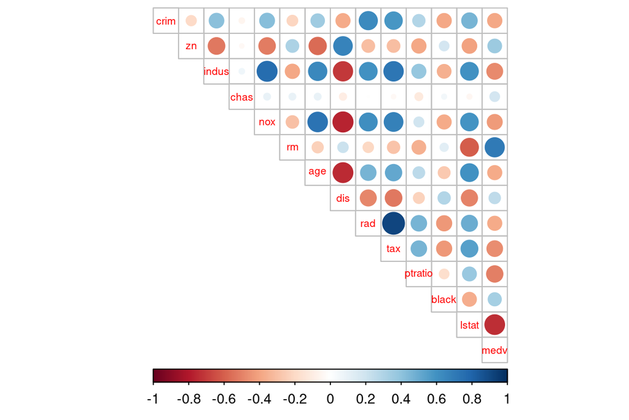

```r
# calculate the correlation matrix and round it to see relationships between the variables
cor_matrix <- cor(Boston) %>% round(digits=2)

# visualize the correlation matrix
corrplot(cor_matrix, method="circle", type="upper", cl.pos = "b", tl.pos = "d", tl.cex = 0.6)
```

## Exercise 4 - Standardization of the data

*Standardize the dataset and print out summaries of the scaled data. How did the variables change?*

```r
# center and standardize variables
boston_scaled <- Boston %>% scale()

# summary of the scaled variables
summary(boston_scaled)
```

```
##       crim                 zn               indus              chas
##  Min.   :-0.419367   Min.   :-0.48724   Min.   :-1.5563   Min.   :-0.2723
##  1st Qu.:-0.410563   1st Qu.:-0.48724   1st Qu.:-0.8668   1st Qu.:-0.2723
##  Median :-0.390280   Median :-0.48724   Median :-0.2109   Median :-0.2723
##  Mean   : 0.000000   Mean   : 0.00000   Mean   : 0.0000   Mean   : 0.0000
##  3rd Qu.: 0.007389   3rd Qu.: 0.04872   3rd Qu.: 1.0150   3rd Qu.:-0.2723
##  Max.   : 9.924110   Max.   : 3.80047   Max.   : 2.4202   Max.   : 3.6648
##       nox                rm               age               dis
##  Min.   :-1.4644   Min.   :-3.8764   Min.   :-2.3331   Min.   :-1.2658
##  1st Qu.:-0.9121   1st Qu.:-0.5681   1st Qu.:-0.8366   1st Qu.:-0.8049
##  Median :-0.1441   Median :-0.1084   Median : 0.3171   Median :-0.2790
##  Mean   : 0.0000   Mean   : 0.0000   Mean   : 0.0000   Mean   : 0.0000
##  3rd Qu.: 0.5981   3rd Qu.: 0.4823   3rd Qu.: 0.9059   3rd Qu.: 0.6617
##  Max.   : 2.7296   Max.   : 3.5515   Max.   : 1.1164   Max.   : 3.9566
##       rad               tax             ptratio            black
##  Min.   :-0.9819   Min.   :-1.3127   Min.   :-2.7047   Min.   :-3.9033
##  1st Qu.:-0.6373   1st Qu.:-0.7668   1st Qu.:-0.4876   1st Qu.: 0.2049
##  Median :-0.5225   Median :-0.4642   Median : 0.2746   Median : 0.3808
##  Mean   : 0.0000   Mean   : 0.0000   Mean   : 0.0000   Mean   : 0.0000
##  3rd Qu.: 1.6596   3rd Qu.: 1.5294   3rd Qu.: 0.8058   3rd Qu.: 0.4332
##  Max.   : 1.6596   Max.   : 1.7964   Max.   : 1.6372   Max.   : 0.4406
##      lstat              medv
##  Min.   :-1.5296   Min.   :-1.9063
##  1st Qu.:-0.7986   1st Qu.:-0.5989
##  Median :-0.1811   Median :-0.1449
##  Mean   : 0.0000   Mean   : 0.0000
##  3rd Qu.: 0.6024   3rd Qu.: 0.2683
##  Max.   : 3.5453   Max.   : 2.9865
```

```r
# change the object to data frame
boston_scaled <- boston_scaled %>% as.data.frame()
```

The ranges of the variables are clearly much more even now, and for example tax that ranged from 187 to 711 or black (1000(Bk - 0.63)^2 where Bk is the proportion of blacks by town) that ranged from 0.32 to 396.9 won’t dominate in the LDA analysis.

*Create a categorical variable of the crime rate in the Boston dataset (from the scaled crime rate). Use the quantiles as the break points in the categorical variable. Drop the old crime rate variable from the dataset.*

```r
# convert scaled crim into numerical
#boston_scaled$crim <- as.numeric(boston_scaled$crim)
# create a quantile vector of crim
bins <- quantile(boston_scaled$crim)

# create a categorical variable 'crime'
values =c("low", "med_low", "med_high", "high")
crime <- cut(boston_scaled$crim, breaks = bins, include.lowest = TRUE, label= values)

# look at the table of the new factor crime
crime %>% table()
```

```
## .
##      low  med_low med_high     high
##      127      126      126      127
```

```r
# remove original crim from the dataset
boston_scaled <- dplyr::select(boston_scaled, -crim)

# add the new categorical value to scaled data
boston_scaled <- data.frame(boston_scaled, crime)
```

*Divide the dataset to train and test sets, so that 80% of the data belongs to the train set.*

```r
# number of rows in the Boston dataset
n <- nrow(boston_scaled)

# choose randomly 80% of the rows
ind <- sample(n,  size = n * 0.8)

# create train set
train <- boston_scaled[ind,]

# create test set
test <- boston_scaled[-ind,]
```

## Exercise 5 - Fitting LDA

*Fit the linear discriminant analysis on the train set. Use the categorical crime rate as the target variable and all the other variables in the dataset as predictor variables. Draw the LDA (bi)plot.*

```r
# fit linear discriminant analysis with crime as the target and other variables as predictors
lda.fit <- lda(crime ~., data = train)

# print the lda.fit object
lda.fit
```

```
## Call:
## lda(crime ~ ., data = train)
##
## Prior probabilities of groups:
##       low   med_low  med_high      high
## 0.2524752 0.2500000 0.2524752 0.2450495
##
## Group means:
##                   zn      indus         chas        nox         rm        age
## low       0.93022750 -0.8625598 -0.156532002 -0.8601613  0.4412396 -0.8828205
## med_low  -0.05528488 -0.3587476 -0.077423115 -0.6225668 -0.1317433 -0.4206649
## med_high -0.35944951  0.1912361  0.075062130  0.4551033  0.1032595  0.4242014
## high     -0.48724019  1.0149946  0.006051757  1.0830987 -0.4915217  0.8402244
##                 dis        rad        tax     ptratio       black       lstat
## low       0.8264333 -0.6925025 -0.7352305 -0.36800467  0.38284360 -0.76822001
## med_low   0.4455870 -0.5327183 -0.5115043 -0.08373244  0.34687980 -0.16894261
## med_high -0.3990948 -0.4616832 -0.3225676 -0.37389170  0.06506699 -0.01926507
## high     -0.8963723  1.6596029  1.5294129  0.80577843 -0.87577244  0.91395848
##                  medv
## low       0.520468342
## med_low   0.005260547
## med_high  0.184898093
## high     -0.684721270
##
## Coefficients of linear discriminants:
##                  LD1         LD2         LD3
## zn       0.135325549  0.55650595 -1.11002230
## indus   -0.033746976 -0.15463311  0.27913038
## chas     0.008071092  0.08332910  0.12410661
## nox      0.332447286 -1.02040669 -1.16058221
## rm      -0.024051191 -0.08772012 -0.19020058
## age      0.198302858 -0.34537539  0.01085575
## dis     -0.182109993 -0.29770048  0.36915040
## rad      3.982121711  1.12566308  0.06609714
## tax      0.134856193 -0.20051052  0.34649616
## ptratio  0.216332336  0.03377439 -0.42087200
## black   -0.163677922  0.05922587  0.15995705
## lstat    0.166517729 -0.17673775  0.39644129
## medv     0.126688895 -0.45394010 -0.10790973
##
## Proportion of trace:
##    LD1    LD2    LD3
## 0.9630 0.0278 0.0092
```

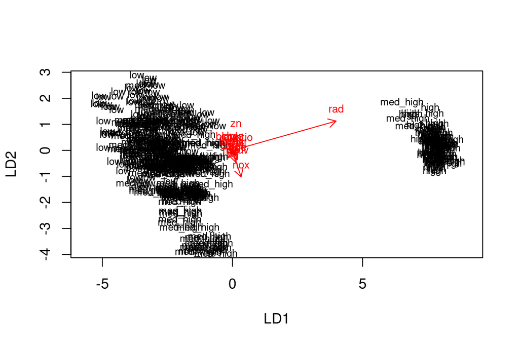

```r
# the function for lda biplot arrows
lda.arrows <- function(x, myscale = 1, arrow_heads = 0.1, color = "red", tex = 0.75, choices = c(1,2)){
  heads <- coef(x)
  graphics::arrows(x0 = 0, y0 = 0,
         x1 = myscale * heads[,choices[1]],
         y1 = myscale * heads[,choices[2]], col=color, length = arrow_heads)
  text(myscale * heads[,choices], labels = row.names(heads),
       cex = tex, col=color, pos=3)
}

# target classes as numeric
classes <- as.numeric(train$crime)

# plot the lda results
plot(lda.fit, dimen = 2)
lda.arrows(lda.fit, myscale = 1)
```

## Exercise 6 - Prediction

*Save the crime categories from the test set and then remove the categorical crime variable from the test dataset. Then predict the classes with the LDA model on the test data. Cross tabulate the results with the crime categories from the test set. Comment on the results.*

```r
# save the correct classes from test data
correct_classes <- test$crime

# remove the crime variable from test data
test <- dplyr::select(test, -crime)

# predict classes with test data
lda.pred <- predict(lda.fit, newdata = test)

# cross tabulate the results
table(correct = correct_classes, predicted = lda.pred$class)
```

```
##           predicted
## correct    low med_low med_high high
##   low       15      10        0    0
##   med_low    4      12        9    0
##   med_high   0      10       11    3
##   high       0       0        1   27
```

## Exercise 7 - K-means clustering

*Reload the Boston dataset and standardize the dataset. Calculate the distances between the observations.*

```r
data("Boston")

# scale and convert into data.frame
boston_scaled <- as.data.frame(scale(Boston))

# euclidean distance matrix
dist_eu <- dist(boston_scaled)

# look at the summary of the distances
summary(dist_eu)
```

```
##    Min. 1st Qu.  Median    Mean 3rd Qu.    Max.
##  0.1343  3.4625  4.8241  4.9111  6.1863 14.3970
```

*Run k-means algorithm on the dataset. Investigate what is the optimal number of clusters and run the algorithm again. Visualize the clusters (for example with the pairs() or ggpairs() functions, where the clusters are separated with colors) and interpret the results*

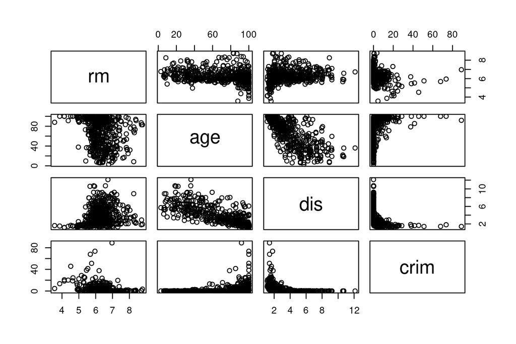

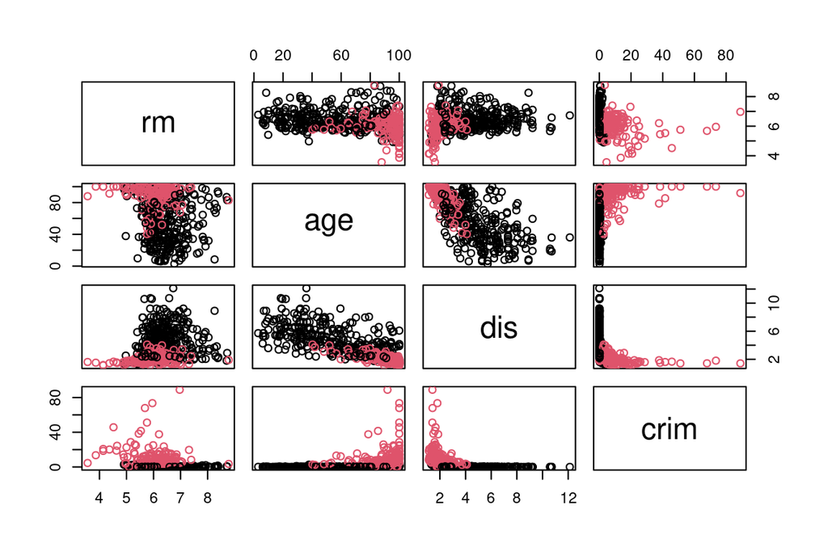

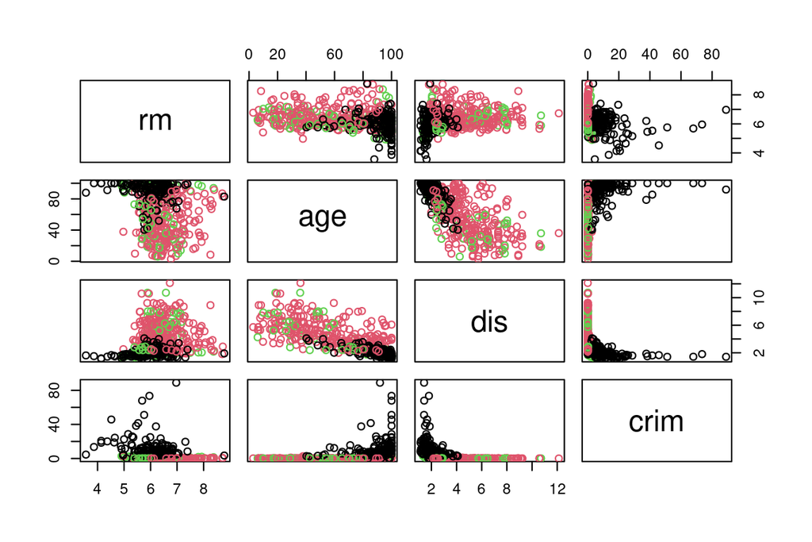

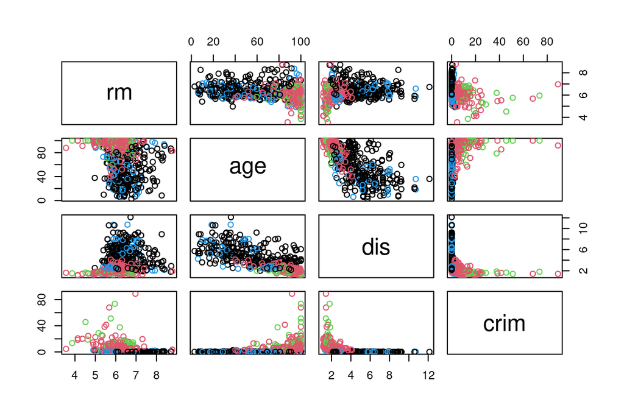

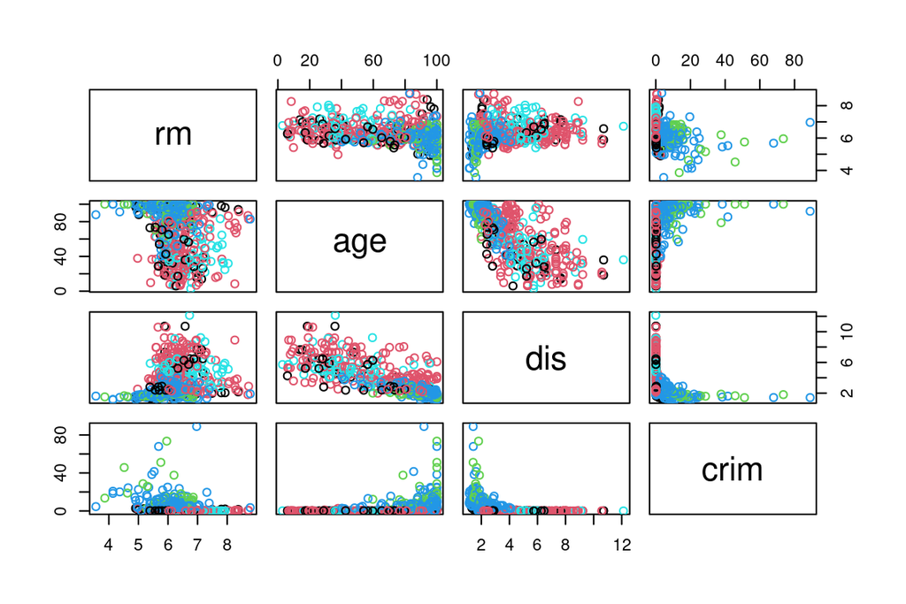

```r
# k-means clustering with clusters 1 to 5 and plotting
for (i in 1:5) {
  km <- kmeans(Boston, centers = i)
  pairs(Boston[, c("rm", "age", "dis", "crim")], col = km$cluster)
}
```

K = 4 an K = 5 seem to be too many, because the clusters overlap. 2 or 3 is maybe more suitable.

# Chapter 5

## Exercise 1 - Graphical overview

*Move the country names to rownames. Show a graphical overview of the data and show summaries of the variables in the data. Describe and interpret the outputs, commenting on the distributions of the variables and the relationships between them.*

```r
human <- read.csv('./data/human.csv', header = T)
dim(human)
```

```
## [1] 155   9
```

```r
human <- column_to_rownames(human, "Country")
head(human)
```

```
##             Sec_edu_ratio LFPR_ratio Edu_years Life_exp   GNI Mat_mort
## Norway          1.0072389  0.8908297      17.5     81.6 64992        4
## Australia       0.9968288  0.8189415      20.2     82.4 42261        6
## Switzerland     0.9834369  0.8251001      15.8     83.0 56431        6
## Denmark         0.9886128  0.8840361      18.7     80.2 44025        5
## Netherlands     0.9690608  0.8286119      17.9     81.6 45435        6
## Germany         0.9927835  0.8072289      16.5     80.9 43919        7
##             Adol_birth_rate Rep_parl
## Norway                  7.8     39.6
## Australia              12.1     30.5
## Switzerland             1.9     28.5
## Denmark                 5.1     38.0
## Netherlands             6.2     36.9
## Germany                 3.8     36.9
```

```r
dim(human)
```

```
## [1] 155   8
```

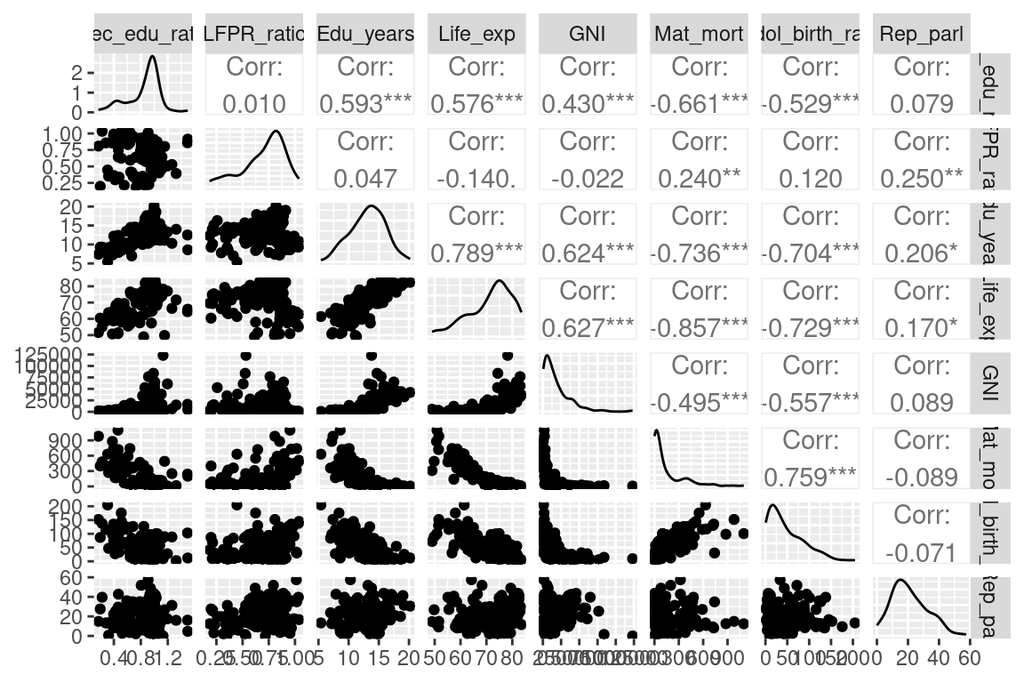

```r
ggpairs(human, progress = FALSE)
```

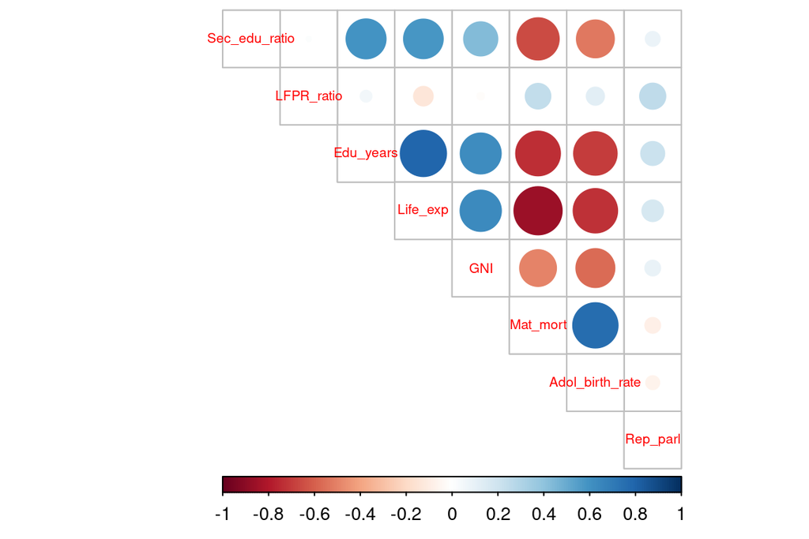

```r
cor_matrix <- cor(human) %>% round(digits=2)
corrplot(cor_matrix, method="circle", type="upper", cl.pos = "b", tl.pos = "d", tl.cex = 0.6)
```

From the ggpairs plot we can see that many variables are not normally distributed, such as `GNI` and `Mat_mort`. Many of the variables are strongly correlated. From the correlation plot we can confirm that many variables have strong positive and negative correlations, but that the variables `LFPR_ratio` and `Rep_parl` don’t seem to correlate as much with the other variables.

## Excercise 2 - PCA on non-standardized data

*Perform principal component analysis (PCA) on the raw (non-standardized) human data. Show the variability captured by the principal components. Draw a biplot displaying the observations by the first two principal components (PC1 coordinate in x-axis, PC2 coordinate in y-axis), along with arrows representing the original variables*

```r
# perform PCA on non-standardized data
pca_human <- prcomp(human)
summary(pca_human) # proportion of variance and cumulative proportion captured by the components
```

```
## Importance of components:
##                              PC1      PC2   PC3   PC4   PC5   PC6    PC7    PC8
## Standard deviation     1.854e+04 185.5219 25.19 11.45 3.766 1.566 0.1912 0.1591
## Proportion of Variance 9.999e-01   0.0001  0.00  0.00 0.000 0.000 0.0000 0.0000
## Cumulative Proportion  9.999e-01   1.0000  1.00  1.00 1.000 1.000 1.0000 1.0000
```

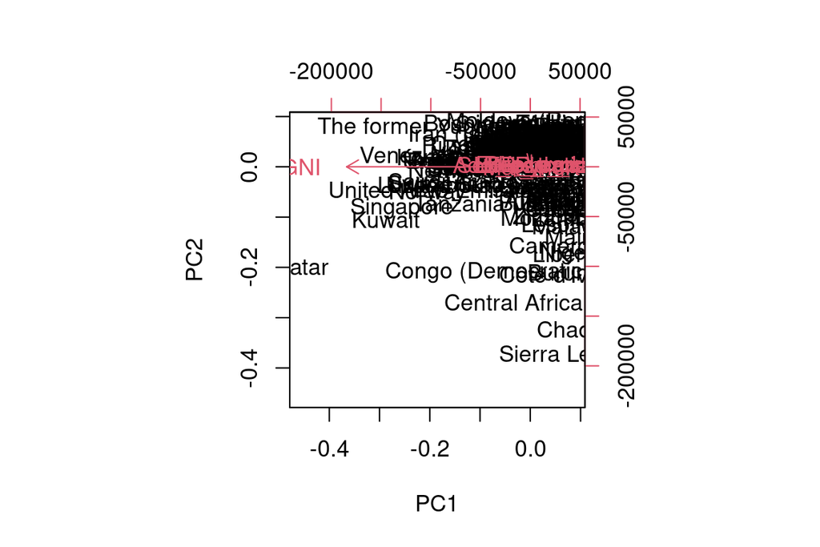

```r
# draw biplot
biplot(pca_human, choices = 1:2)
```

Since GNI has a lot wider range of values than the other variables and the data hasn’t been standardized, GNI dominates the analysis. Pretty much all the variability in the data is explained by GNI alone and the first principal component explains the majority of the variation.

## Excercise 3 - PCA on standardized data

*Standardize the variables in the human data and repeat the above analysis. Interpret the results of both analysis (with and without standardizing). Are the results different? Why or why not? Include captions (brief descriptions) in your plots where you describe the results by using not just your variable names, but the actual phenomena they relate to.*

```r
# standardize data
human_std <- scale(human)

# perform PCA on standardized data
pca_human_std <- prcomp(human_std)
summary(pca_human_std)
```

```
## Importance of components:
##                           PC1    PC2     PC3     PC4     PC5     PC6     PC7
## Standard deviation     2.0708 1.1397 0.87505 0.77886 0.66196 0.53631 0.45900
## Proportion of Variance 0.5361 0.1624 0.09571 0.07583 0.05477 0.03595 0.02634
## Cumulative Proportion  0.5361 0.6984 0.79413 0.86996 0.92473 0.96069 0.98702
##                            PC8
## Standard deviation     0.32224
## Proportion of Variance 0.01298
## Cumulative Proportion  1.00000
```

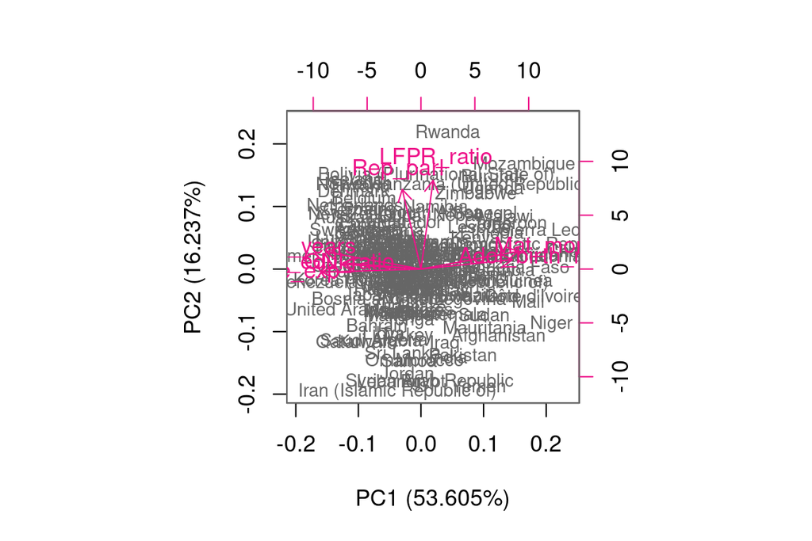

```r
# create and print out a summary of pca_human
s <- summary(pca_human_std)

# rounded percentanges of variance captured by each PC
pca_pr <- round(1*s$importance[2, ], digits = 5)

# create object pc_lab to be used as axis labels
pc_lab <- paste0(names(pca_pr), " (", pca_pr * 100, "%)")

# draw a biplot Use the first value of the `pc_lab` vector as the label for the x-axis and the second value as the label for the y-axis

biplot(pca_human_std, cex = c(0.8, 1), col = c("grey40", "deeppink2"), xlab = pc_lab[1], ylab = pc_lab[2])
```

The biplot looks different, since after scaling the data, the variables contribute equally to the analysis. The biplot is much more even now. The first principal component now explains 54% of the variation.

## Excercise 4 - Interpretations of the first two principal component dimensions

*Give your personal interpretations of the first two principal component dimensions based on the biplot drawn after PCA on the standardized human data.*

Biplot shows how strongly each characteristic influences a principal component. We can see that PC1 is is influenced by factors such as `years of education` and `life expectancy`, which are positively correlated with each other, as well as `Mat_mort`, which is negatively correlated with the other 2. PC2 is influenced by `LFPR_ratio` and `Rep_parl`, which are also positively correlated with each other.

## Excercise 5 - Visualization of Tea data

*Load the tea dataset and convert its character variables to factors. Explore the data briefly: look at the structure and the dimensions of the data. Use View(tea) to browse its contents, and visualize the data.*

```r
tea <- read.csv("https://raw.githubusercontent.com/KimmoVehkalahti/Helsinki-Open-Data-Science/master/datasets/tea.csv", stringsAsFactors = TRUE)
str(tea)
```

```
## 'data.frame':    300 obs. of  36 variables:
##  $ breakfast       : Factor w/ 2 levels "breakfast","Not.breakfast": 1 1 2 2 1 2 1 2 1 1 ...
##  $ tea.time        : Factor w/ 2 levels "Not.tea time",..: 1 1 2 1 1 1 2 2 2 1 ...
##  $ evening         : Factor w/ 2 levels "evening","Not.evening": 2 2 1 2 1 2 2 1 2 1 ...
##  $ lunch           : Factor w/ 2 levels "lunch","Not.lunch": 2 2 2 2 2 2 2 2 2 2 ...
##  $ dinner          : Factor w/ 2 levels "dinner","Not.dinner": 2 2 1 1 2 1 2 2 2 2 ...
##  $ always          : Factor w/ 2 levels "always","Not.always": 2 2 2 2 1 2 2 2 2 2 ...
##  $ home            : Factor w/ 2 levels "home","Not.home": 1 1 1 1 1 1 1 1 1 1 ...
##  $ work            : Factor w/ 2 levels "Not.work","work": 1 1 2 1 1 1 1 1 1 1 ...
##  $ tearoom         : Factor w/ 2 levels "Not.tearoom",..: 1 1 1 1 1 1 1 1 1 2 ...
##  $ friends         : Factor w/ 2 levels "friends","Not.friends": 2 2 1 2 2 2 1 2 2 2 ...
##  $ resto           : Factor w/ 2 levels "Not.resto","resto": 1 1 2 1 1 1 1 1 1 1 ...
##  $ pub             : Factor w/ 2 levels "Not.pub","pub": 1 1 1 1 1 1 1 1 1 1 ...
##  $ Tea             : Factor w/ 3 levels "black","Earl Grey",..: 1 1 2 2 2 2 2 1 2 1 ...
##  $ How             : Factor w/ 4 levels "alone","lemon",..: 1 3 1 1 1 1 1 3 3 1 ...
```

[output cut: 22 more lines]

```r
# There are no character variables, so I'm not sure what should be converted here..
summary(tea)
```

```
##          breakfast           tea.time          evening          lunch
##  breakfast    :144   Not.tea time:131   evening    :103   lunch    : 44
##  Not.breakfast:156   tea time    :169   Not.evening:197   Not.lunch:256
##
##
##
##
##
##         dinner           always          home           work
##  dinner    : 21   always    :103   home    :291   Not.work:213
##  Not.dinner:279   Not.always:197   Not.home:  9   work    : 87
##
##
##
##
##
##         tearoom           friends          resto          pub
##  Not.tearoom:242   friends    :196   Not.resto:221   Not.pub:237
##  tearoom    : 58   Not.friends:104   resto    : 79   pub    : 63
##
##
##
##
##
##         Tea         How           sugar                     how
##  black    : 74   alone:195   No.sugar:155   tea bag           :170
##  Earl Grey:193   lemon: 33   sugar   :145   tea bag+unpackaged: 94
##  green    : 33   milk : 63                  unpackaged        : 36
##                  other:  9
##
##
##
##                   where                 price          age        sex
##  chain store         :192   p_branded      : 95   Min.   :15.00   F:178
##  chain store+tea shop: 78   p_cheap        :  7   1st Qu.:23.00   M:122
##  tea shop            : 30   p_private label: 21   Median :32.00
##                             p_unknown      : 12   Mean   :37.05
##                             p_upscale      : 53   3rd Qu.:48.00
##                             p_variable     :112   Max.   :90.00
##
```

[output cut: 25 more lines]

```
##  feminine    :129   Not.sophisticated: 85   No.slimming:255   exciting   :116
##  Not.feminine:171   sophisticated    :215   slimming   : 45   No.exciting:184
##
##
##
##
##
##         relaxing              effect.on.health
##  No.relaxing:113   effect on health   : 66
##  relaxing   :187   No.effect on health:234
##
##
##
##
##
```

```r
# make a smaller data set of 'tea'
keep_columns <- c("breakfast", "evening", "work", "Tea", "sugar", "sex", "Sport", "relaxing", "effect.on.health")

# select the 'keep_columns' to create a new dataset
tea_time <- dplyr::select(tea, keep_columns)
```

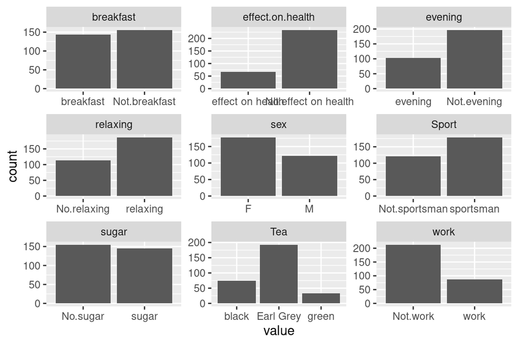

```r
# ggplot
pivot_longer(tea_time, cols = everything()) %>%
  ggplot(aes(value)) + facet_wrap("name", scales = "free") + geom_bar()
```

## Exercise 5 - Multiple Correspondence Analysis (MCA)

*Use Multiple Correspondence Analysis (MCA) on the tea data (or on just certain columns of the data, it is up to you!). Interpret the results of the MCA and draw at least the variable biplot of the analysis. You can also explore other plotting options for MCA. Comment on the output of the plots.*

```r
# multiple correspondence analysis
mca <- MCA(tea_time, graph = FALSE)

# summary of the model
summary(mca)
```

```
##
## Call:
## MCA(X = tea_time, graph = FALSE)
##
##
## Eigenvalues
##                        Dim.1   Dim.2   Dim.3   Dim.4   Dim.5   Dim.6   Dim.7
## Variance               0.162   0.145   0.134   0.132   0.119   0.102   0.091
## % of var.             14.570  13.059  12.047  11.859  10.720   9.215   8.149
## Cumulative % of var.  14.570  27.629  39.676  51.534  62.254  71.470  79.619
##                        Dim.8   Dim.9  Dim.10
## Variance               0.083   0.078   0.066
## % of var.              7.453   7.008   5.919
## Cumulative % of var.  87.072  94.081 100.000
##
## Individuals (the 10 first)
##                  Dim.1    ctr   cos2    Dim.2    ctr   cos2    Dim.3    ctr
## 1             |  0.007  0.000  0.000 |  0.199  0.091  0.035 |  0.407  0.412
## 2             |  0.500  0.515  0.242 | -0.187  0.080  0.034 |  0.595  0.880
## 3             | -0.303  0.190  0.092 | -0.444  0.452  0.196 | -0.082  0.017
## 4             | -0.230  0.109  0.065 |  0.383  0.337  0.181 | -0.314  0.246
## 5             | -0.503  0.522  0.288 | -0.009  0.000  0.000 |  0.387  0.373
## 6             | -0.115  0.027  0.019 |  0.192  0.085  0.052 |  0.071  0.013
## 7             | -0.154  0.049  0.033 | -0.086  0.017  0.010 |  0.324  0.262
## 8             | -0.160  0.053  0.024 |  0.142  0.046  0.019 |  0.593  0.877
## 9             | -0.154  0.049  0.033 | -0.086  0.017  0.010 |  0.324  0.262
## 10            | -0.179  0.066  0.026 |  0.205  0.096  0.034 |  0.849  1.796
##                 cos2
## 1              0.146 |
## 2              0.342 |
## 3              0.007 |
## 4              0.122 |
## 5              0.170 |
## 6              0.007 |
## 7              0.145 |
## 8              0.334 |
## 9              0.145 |
## 10             0.578 |
##
## Categories (the 10 first)
```

[output cut: 19 more lines]

```
## Earl Grey      -7.385 |  -0.494  13.026   0.440 -11.469 |
## green           9.062 |  -0.136   0.169   0.002  -0.826 |
## No.sugar       -3.498 |   0.458   8.987   0.224   8.184 |
##
## Categorical variables (eta2)
##                    Dim.1 Dim.2 Dim.3
## breakfast        | 0.005 0.226 0.174 |
## evening          | 0.360 0.016 0.010 |
## work             | 0.001 0.478 0.030 |
## Tea              | 0.121 0.316 0.608 |
## sugar            | 0.324 0.041 0.224 |
## sex              | 0.101 0.204 0.026 |
## Sport            | 0.126 0.015 0.025 |
## relaxing         | 0.379 0.002 0.091 |
## effect.on.health | 0.041 0.008 0.018 |
```

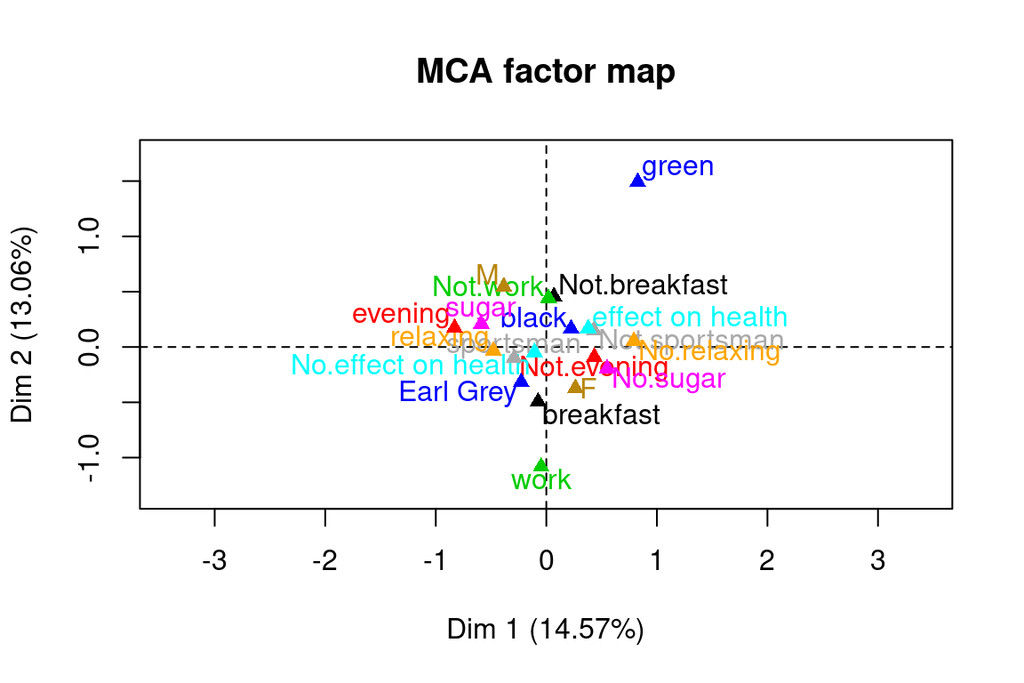

```r
# visualize the model
plot(mca, invisible=c("ind"), graph.type = "classic", habillage = "quali")
```

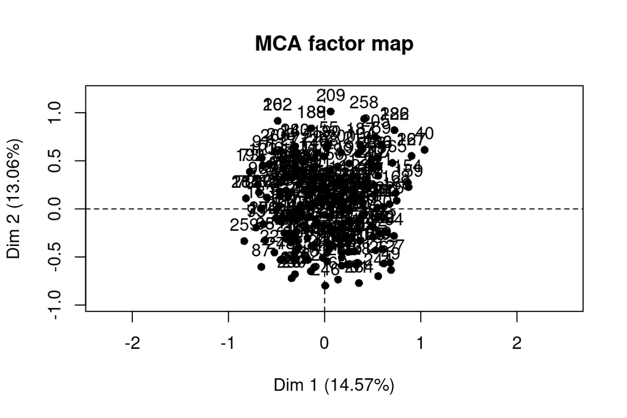

```r
plot(mca, invisible=c("var"), graph.type = "classic", habillage = "quali")
```

The distance between variables gives a measure of their similarity (or dissimilarity). For example `Relaxing` and `evening` seem to contribute most to Dim 1, whereas variables `work` and `Tea` contribute greatly to Dim2.

From the individuals’ scatterplot we can see that there is no particular group of individuals, the scatterplot is quite homogeneous.